# Clustering

Jeffrey Hunt, Anmoldeep Sadeep

10-16-2022

## Problem Statement

The problem statement is to choose the data sets and then we need to apply the data mining algorithms for clustering and then we need to provide the analysis of our data. Our main task is to do this with two different algorithms, so we are going to use the k-means clustering algorithm, and association rules mining algorithm. With the help of these algorithms we are going to do the analysis of the data.

## Part 1 Explain Data Mining Techniques: Clustering, Association, Coorelation Analysis

Clustering: The process of clustering involves grouping the population or data points into a number of groups so that the data points within each group are more similar to one another than the data points within other groups. For example: the goal is to sort into clusters any groups of people who share similar characteristics.

Association: Data mining technique called association determines the likelihood of elements in a collection occurring together. Association Rules are used to express the links between co-occurring things. An example of illustration of association rule mining involves the connection between diapers and beers. The scenario, which appears to be made up, suggests that males are more inclined to purchase beer when they visit a store to buy diapers. Data that would support that might appear something like this: 200,000 customers trade in a supermarket.

Correlation Analysis: It is a statistical method used to measure the strength of the linear relationship between two variables and compute their association, basically it measures the closeness of relationships. For example: the degree to which the variables are associated with each other.

# K-means

### Install Libraries

```r
library(tidyverse)
library(cluster)
library(stats)
library(factoextra)
```

```r
library(ggplot2)
library(clue)

# R Libraries
library(arules)
library(arulesViz)
```

### Data Exploration

```r
data <- read.csv("online_shopper_intention.csv")
data.df <- data.frame(data)

head(data.df)
```

|  | Administrative | Administrative_Duration | Informational | Informational_Duration | ProductRelated | ProductRelated_Duration | BounceRates | ExitRates | PageValues | SpecialDay | Month | OperatingSystems | Browser | Region | TrafficType | VisitorType | Weekend | Revenue |
| --- | --- | --- | --- | --- | --- | --- | --- | --- | --- | --- | --- | --- | --- | --- | --- | --- | --- | --- |
| 1 | 0 | 0 | 0 | 0 | 1 | 0.000000 | 0.20000000 | 0.2000000 | 0 | 0 | Feb | 1 | 1 | 1 | 1 | Returning_Visitor | FALSE | FALSE |
| 2 | 0 | 0 | 0 | 0 | 2 | 64.000000 | 0.00000000 | 0.1000000 | 0 | 0 | Feb | 2 | 2 | 1 | 2 | Returning_Visitor | FALSE | FALSE |
| 3 | 0 | 0 | 0 | 0 | 1 | 0.000000 | 0.20000000 | 0.2000000 | 0 | 0 | Feb | 4 | 1 | 9 | 3 | Returning_Visitor | FALSE | FALSE |
| 4 | 0 | 0 | 0 | 0 | 2 | 2.666667 | 0.05000000 | 0.1400000 | 0 | 0 | Feb | 3 | 2 | 2 | 4 | Returning_Visitor | FALSE | FALSE |
| 5 | 0 | 0 | 0 | 0 | 10 | 627.500000 | 0.02000000 | 0.0500000 | 0 | 0 | Feb | 3 | 3 | 1 | 4 | Returning_Visitor | TRUE | FALSE |
| 6 | 0 | 0 | 0 | 0 | 19 | 154.216667 | 0.01578947 | 0.0245614 | 0 | 0 | Feb | 2 | 2 | 1 | 3 | Returning_Visitor | FALSE | FALSE |

### Data Preprocessing

- Keep only the data that has numeric types.

```r
# Keep only data with integer or double value types
#Get rid of all the columns that have lots of 0's
#  It may Skew the data

data.df <- data.df[, -c(1, 2, 3, 4, 9, 10, 11, 16, 17, 18)]

head(data.df)
```

|  | ProductRelated | ProductRelated_Duration | BounceRates | ExitRates | OperatingSystems | Browser | Region | TrafficType |
| --- | --- | --- | --- | --- | --- | --- | --- | --- |
| 1 | 1 | 0.000000 | 0.20000000 | 0.2000000 | 1 | 1 | 1 | 1 |
| 2 | 2 | 64.000000 | 0.00000000 | 0.1000000 | 2 | 2 | 1 | 2 |
| 3 | 1 | 0.000000 | 0.20000000 | 0.2000000 | 4 | 1 | 9 | 3 |
| 4 | 2 | 2.666667 | 0.05000000 | 0.1400000 | 3 | 2 | 2 | 4 |
| 5 | 10 | 627.500000 | 0.02000000 | 0.0500000 | 3 | 3 | 1 | 4 |
| 6 | 19 | 154.216667 | 0.01578947 | 0.0245614 | 2 | 2 | 1 | 3 |

### Data Normalizing

- We scale the data so that we what set of data will not control how most of the algorithm sways.

```r
# Scale all of the Data
# ? Ask Professor if this the right practice to do or not
data.df <- scale(data.df)

head(data.df)
```

```
##      ProductRelated ProductRelated_Duration BounceRates  ExitRates
## [1,]     -0.6909752              -0.6243222  3.66704008  3.2291846
## [2,]     -0.6684909              -0.5908786 -0.45766444  1.1714250
## [3,]     -0.6909752              -0.6243222  3.66704008  3.2291846
## [4,]     -0.6684909              -0.6229287  0.57351169  1.9945289
## [5,]     -0.4886166              -0.2964181 -0.04519398  0.1425452
## [6,]     -0.2862580              -0.5437353 -0.13202986 -0.3809200
##      OperatingSystems    Browser     Region TrafficType
## [1,]       -1.2333763 -0.7902608 -0.8941422 -0.76259811
## [2,]       -0.1360728 -0.2079435 -0.8941422 -0.51416134
## [3,]        2.0585344 -0.7902608  2.4369825 -0.26572458
## [4,]        0.9612308 -0.2079435 -0.4777516 -0.01728781
## [5,]        0.9612308  0.3743739 -0.8941422 -0.01728781
## [6,]       -0.1360728 -0.2079435 -0.8941422 -0.26572458
```

### Elbow Method (Determine best number for K)

The greatest bend in the elbow graph determines what the optimal numbers of K that we should use. From looking at the graph it looks like the best choice is around 3 or 4. We will use 4

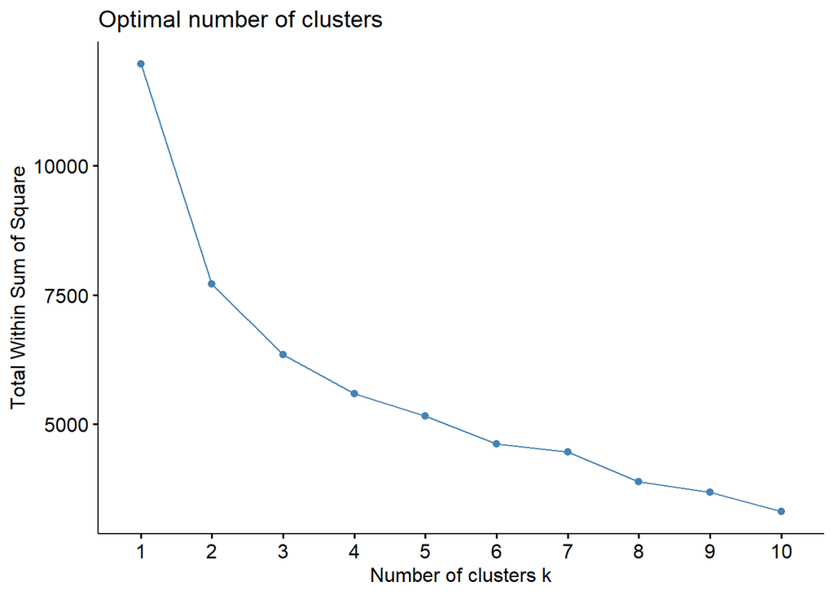

```r
elbow <- data.df[1:2000, ] #get just the the 2000 so it does not take forever to get the elbow Graph

fviz_nbclust(elbow, kmeans, method = "wss")
```

### Build the Clustering Model

- We use 4 because that is what the elbow method told us to use for clusters.
- We start at 25 because it is common practice to do for a bigger data set.

```r
model <- kmeans(data.df, 4, nstart = 25)
str(model)
```

```
## List of 9
##  $ cluster     : int [1:12330] 4 1 4 1 1 1 4 4 1 1 ...
##  $ centers     : num [1:4, 1:8] -0.158 -0.154 2.789 -0.659 -0.153 ...
##   ..- attr(*, "dimnames")=List of 2
##   .. ..$ : chr [1:4] "1" "2" "3" "4"
##   .. ..$ : chr [1:8] "ProductRelated" "ProductRelated_Duration" "BounceRates" "ExitRates" ...
##  $ totss       : num 98632
##  $ withinss    : num [1:4] 31231 11966 8836 5346
##  $ tot.withinss: num 57378
##  $ betweenss   : num 41254
##  $ size        : int [1:4] 8878 1730 813 909
##  $ iter        : int 4
##  $ ifault      : int 0
##  - attr(*, "class")= chr "kmeans"
```

### Display Clustering Results

```r
# Quantitative Results
head(model)
```

[output not shown]

[output cut: 353 more lines]

```r
head(data.df)
```

```
##      ProductRelated ProductRelated_Duration BounceRates  ExitRates
## [1,]     -0.6909752              -0.6243222  3.66704008  3.2291846
## [2,]     -0.6684909              -0.5908786 -0.45766444  1.1714250
## [3,]     -0.6909752              -0.6243222  3.66704008  3.2291846
## [4,]     -0.6684909              -0.6229287  0.57351169  1.9945289
## [5,]     -0.4886166              -0.2964181 -0.04519398  0.1425452
## [6,]     -0.2862580              -0.5437353 -0.13202986 -0.3809200
##      OperatingSystems    Browser     Region TrafficType
## [1,]       -1.2333763 -0.7902608 -0.8941422 -0.76259811
## [2,]       -0.1360728 -0.2079435 -0.8941422 -0.51416134
## [3,]        2.0585344 -0.7902608  2.4369825 -0.26572458
## [4,]        0.9612308 -0.2079435 -0.4777516 -0.01728781
## [5,]        0.9612308  0.3743739 -0.8941422 -0.01728781
## [6,]       -0.1360728 -0.2079435 -0.8941422 -0.26572458
```

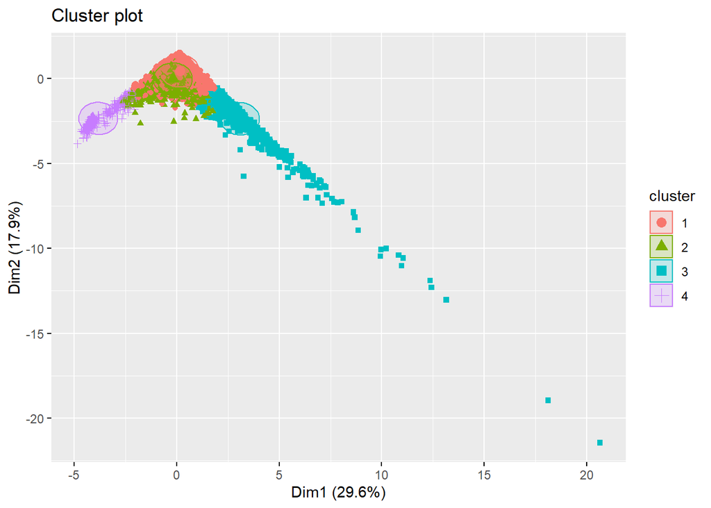

```r
#Visual Results
fviz_cluster(model, data = data.df, geom = c("point"), ellipse.type = "euclid")
```

### Make predictions and view the mean

```r
aggregate(data.df, by=list(cluster=model$cluster), mean)
```

| cluster | ProductRelated | ProductRelated_Duration | BounceRates | ExitRates | OperatingSystems | Browser | Region | TrafficType |
| --- | --- | --- | --- | --- | --- | --- | --- | --- |
| 1 | -0.1579471 | -0.1529041 | -0.2711575 | -0.2359037 | -0.096274188 | -0.02796165 | 0.001815133 | -0.3824434 |
| 2 | -0.1538866 | -0.1362792 | -0.1702264 | -0.1230657 | 0.467127067 | 0.17342388 | 0.078238112 | 1.9725040 |
| 3 | 2.7888071 | 2.6347890 | -0.3419571 | -0.5044836 | 0.004295714 | -0.04535304 | -0.152014349 | -0.2055253 |
| 4 | -0.6587699 | -0.6037817 | 3.2781505 | 2.9894409 | 0.047414744 | -0.01640016 | -0.030669991 | 0.1650085 |

```r
# Make a prediction on a random set
prediction <- data.frame(ProductRelated=-0.5, ProductRelated_Duration=-0.3, BounceRates=0.5, ExitRates=1.5, OperatingSystems=1.5, Browser=0.3, Region=0.5, trafficType=-0.3)

head(prediction)
```

|  | ProductRelated | ProductRelated_Duration | BounceRates | ExitRates | OperatingSystems | Browser | Region | trafficType |
| --- | --- | --- | --- | --- | --- | --- | --- | --- |
| 1 | -0.5 | -0.3 | 0.5 | 1.5 | 1.5 | 0.3 | 0.5 | -0.3 |

```r
print("Prediction for the test set: ")
```

```
## [1] "Prediction for the test set: "
```

```r
cl_predict(model, prediction) #able to predict that the cluster we used will go in the first cluster
```

```
## Class ids:
## [1] 1
```

### Aggregate

We used the aggregate on this program as data.df and we used it because so it can take all the data and can find the mean values and also it will split up for points in each cluster.

### Interpret the Results

The k-means algorithm is taken from the distance formula. From the distance formula it is able to group items items into different clusters giving a certain number of centroids. We find the centroids which are the k value by applying a method known as the Elbow Method. From our data the elbow method is able to tell us what is the best number of K’s to use is, for our example it is 4. Then we are able to run the k-means and make predictions on the dataset. From our graph that we built we are able to see that the clusters are all right next one another with just a few outliers.